# DATA ANALYSIS AND VISUALIZATION Pipeline of antimicrobial agents in clinical development (WHO - Nov 2021)

WHO reviewed the publicly available information on antibacterial agents in pre-clinical and clinical development to assess the drug candidates action against WHO identified bacterial priority pathogens, *Mycobacterium tuberculosis*, and *Clostridium difficile*.

In Nov 2021, a total of 80 products were in clinical development (3 in pre-registration phase). Among these 80 candidates 46 were antibiotics and 34 were non-traditional antibacterial agents. Through this pipeline the products can be explored by type, phase of clinical development, activity against pathogens,innovativeness, route of administration, antibiotic class and developers.

Let’s try to analyse and visualize the data.

```r
# IMPORTING DATA AS CSV FILE
AMR_PRODUCTS <- read.csv(file="AMR_DATA.csv")
head(AMR_PRODUCTS)
```

|  | Data.source | Date.of.update | Product.name | Alternative.name | Product.type | Non.traditionals.categories | Antibacterial.class | Indications | Route.of.administration | R.D.phase | Clinical.trials | Developer | Pathogen.category | Pathogen.name | Pathogen.activity | Active.against.priority.pathogens. | Innovative. | NCE. | Mycobacterium.tuberculosis | Clostridioides.difficile |
| --- | --- | --- | --- | --- | --- | --- | --- | --- | --- | --- | --- | --- | --- | --- | --- | --- | --- | --- | --- | --- |
| 1 | WHO AMR pipeline analysis | Nov-21 | Bacteriophage |  | Non-traditional | Bacteriophages and phage-derived enzymes | Bacteriophage | Gram positive and Gram negative | Inhalation | Phase III | NCT04682964 | Tashkent Pediatric Medical\nInstitute | Priority pathogens | Streptococcus pneumoniae | Other priority pathogens | Yes | N/A | Yes | NA | NA |
| 2 | WHO AMR pipeline analysis | Nov-21 | Bacteriophage |  | Non-traditional | Bacteriophages and phage-derived enzymes | Bacteriophage | Gram positive and Gram negative | Inhalation | Phase III | NCT04682964 | Tashkent Pediatric Medical\nInstitute | Priority pathogens | Staphylococcus aureus | Other priority pathogens | Yes | N/A | Yes | NA | NA |
| 3 | WHO AMR pipeline analysis | Nov-21 | Bacteriophage |  | Non-traditional | Bacteriophages and phage-derived enzymes | Bacteriophage | Gram positive and Gram negative | Inhalation | Phase III | NCT04682964 | Tashkent Pediatric Medical\nInstitute | Priority pathogens | Pseudomonas aeruginosa | Critical priority pathogens | Yes | N/A | Yes | NA | NA |
| 4 | WHO AMR pipeline analysis | Nov-21 | Bacteriophage |  | Non-traditional | Bacteriophages and phage-derived enzymes | Bacteriophage | Gram positive and Gram negative | Inhalation | Phase III | NCT04682964 | Tashkent Pediatric Medical\nInstitute | Priority pathogens | Other priority pathogens | Other priority pathogens | Yes | N/A | Yes | NA | NA |
| 5 | WHO AMR pipeline analysis | Nov-21 | Bacteriophage |  | Non-traditional | Bacteriophages and phage-derived enzymes | Bacteriophage | Gram positive and Gram negative | Inhalation | Phase III | NCT04682964 | Tashkent Pediatric Medical\nInstitute | Priority pathogens | Neisseria gonnorhoeae | Other priority pathogens | N/A | N/A | Yes | NA | NA |
| 6 | WHO AMR pipeline analysis | Nov-21 | Bacteriophage |  | Non-traditional | Bacteriophages and phage-derived enzymes | Bacteriophage | Gram positive and Gram negative | Inhalation | Phase III | NCT04682964 | Tashkent Pediatric Medical\nInstitute | Priority pathogens | Helicobacter pylori | Other priority pathogens | N/A | N/A | Yes | NA | NA |

```r
library(ggplot2)
library(dplyr)
```

```r
# DATA STRATIFICATION
Antibiotics <- AMR_PRODUCTS %>% filter(Product.type == "Antibiotics")
Non_traditional <- AMR_PRODUCTS %>% filter(Product.type == "Non-traditional")

COUNT_1 <- unique(Non_traditional$Product.name)
L1 <- length(COUNT_1)

COUNT_2 <- unique(Antibiotics$Product.name)
L2 <- length(COUNT_2)

PRODUCT_TYPE <- data.frame("Type" = c("Non_traditional","Antibiotics"),"Count" = c(L1,L2))
PRODUCT_TYPE
```

| Type | Count |
| --- | --- |
| Non_traditional | 34 |
| Antibiotics | 46 |

The data was subsetted based on product type. 46 antibiotics and 34 non-traditional agents were found as mentioned.

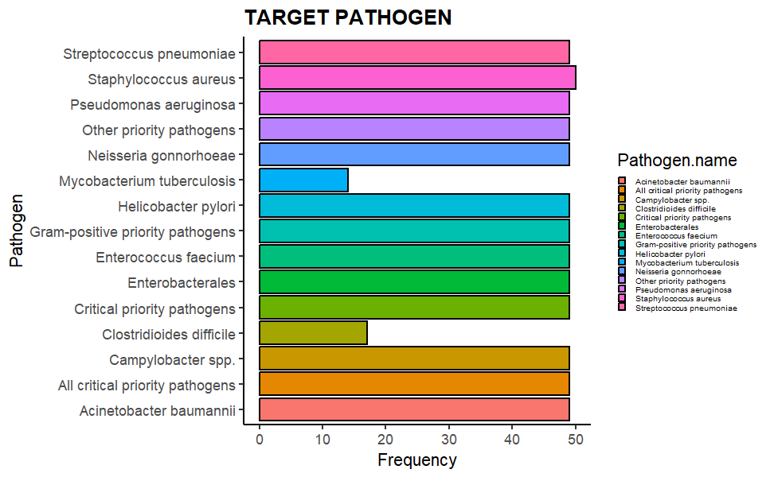

```r
#TARGET PATHOGEN
AMR_PRODUCTS$Pathogen.name <- as.factor(AMR_PRODUCTS$Pathogen.name)
ggplot(data = AMR_PRODUCTS, aes(y= `Pathogen.name`))+ geom_bar(aes(fill = Pathogen.name), color = "black")+ labs(title = "TARGET PATHOGEN", y= "Pathogen", x= "Frequency")+ theme_classic()+ theme(plot.title  = element_text(face = "bold"),legend.key.size = unit(0.2,"cm"), legend.text = element_text(size=5))
```

Most of the drugs studied are targeted at *Staphylococcus aureus*, while the fewest are focused on *Mycobacterium tuberculosis*.

```r
# TARGET OF ANTIMICROBIAL AGENTS: SPECTRUM OF ACTIVITY
Target <- AMR_PRODUCTS %>% select(Pathogen.name, Product.type)
Target <- table(Target)
Target <- as.data.frame(Target)
Target
```

| Pathogen.name | Product.type | Freq |
| --- | --- | --- |
| Acinetobacter baumannii | Antibiotics | 28 |
| All critical priority pathogens | Antibiotics | 28 |
| Campylobacter spp. | Antibiotics | 28 |
| Clostridioides difficile | Antibiotics | 5 |
| Critical priority pathogens | Antibiotics | 28 |
| Enterobacterales | Antibiotics | 28 |
| Enterococcus faecium | Antibiotics | 28 |
| Gram-positive priority pathogens | Antibiotics | 28 |
| Helicobacter pylori | Antibiotics | 28 |
| Mycobacterium tuberculosis | Antibiotics | 13 |

[output cut: 20 more lines]

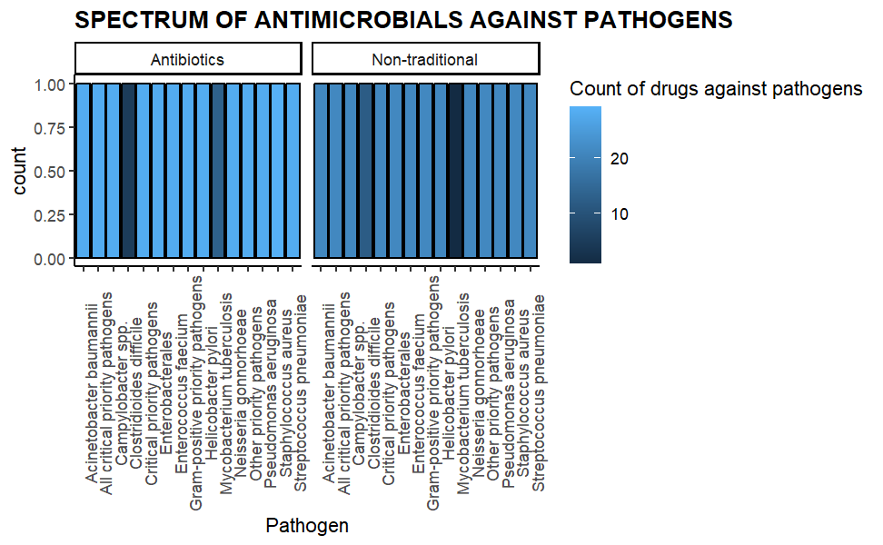

```r
ggplot(Target, aes(x = Pathogen.name, fill = Freq )) + geom_bar(position = "dodge", color="black") + facet_wrap(~ Product.type) + labs(title = "SPECTRUM OF ANTIMICROBIALS AGAINST PATHOGENS", fill = "Count of drugs against pathogens", x= "Pathogen")+ theme_classic()+  theme(plot.title  = element_text(face = "bold")) + theme(axis.text.x = element_text(angle = 90))
```

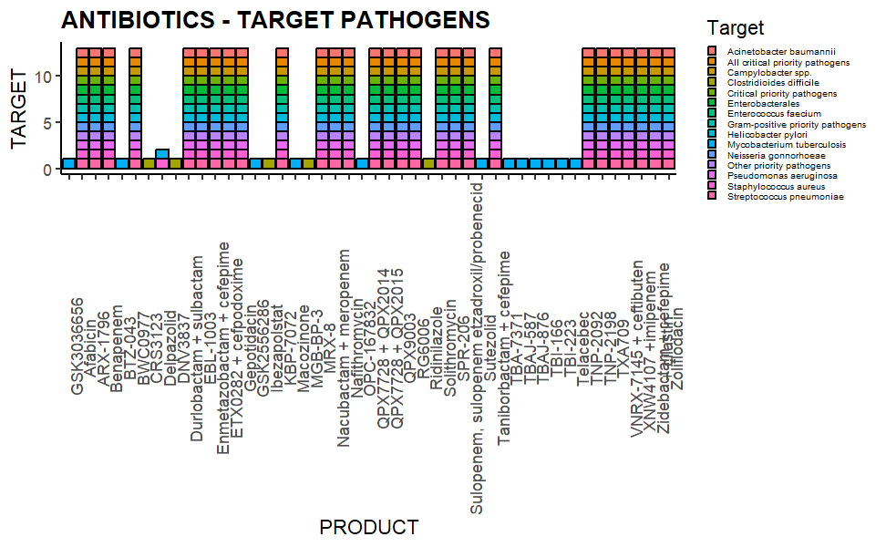

```r
# ANTIBIOTICS - TARGET PATHOGENS
ggplot(data = Antibiotics, aes(x = Product.name)) + geom_bar(aes(fill = Pathogen.name), color ="black")+ labs(title = "ANTIBIOTICS - TARGET PATHOGENS", y = "TARGET", x = "PRODUCT", fill= "Target")+ theme_classic()+  theme(plot.title  = element_text(face = "bold"), legend.key.size = unit(0.2,"cm"), legend.text = element_text(size=5))+ theme(axis.text.x = element_text(angle = 90))
```

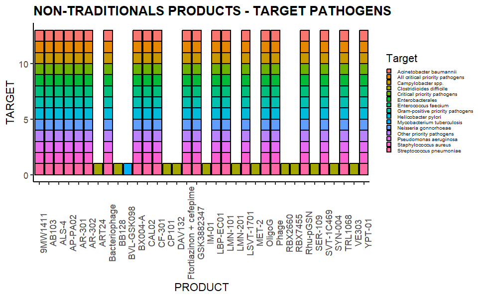

```r
# NON-TRADITIONALS - TARGET PATHOGEN
ggplot(data = Non_traditional, aes(x = Product.name)) + geom_bar(aes(fill = Pathogen.name), color ="black")+ labs(title = "NON-TRADITIONALS PRODUCTS - TARGET PATHOGENS", y = "TARGET", x = "PRODUCT", fill= "Target")+ theme_classic()+  theme(plot.title  = element_text(face = "bold"), legend.key.size = unit(0.2,"cm"), legend.text = element_text(size=5))+ theme(axis.text.x = element_text(angle = 90))
```

From table and graphs, we can infer details on the spectrum of activity of antibiotics and non-traditional. Most of the products are broad-spectrum, effective against all priority pathogens.

Narrow-spectrum antibiotics and non-traditional specifically against *Clostridium difficile* are **CRS3123,DNV3837,Ibezapolstat,MGB-BP-3,Ridinilazole** and **ART24,BB128,DAV132,CP101,IM01,LMN201,MET2,RBX2660,RBX7455,SER101,SYN-004,VE303** respectively.

More antibiotics target *Mycobacterium tuberculosis* when compared to non-traditional and the reverse holds true for *Clostridium difficile*

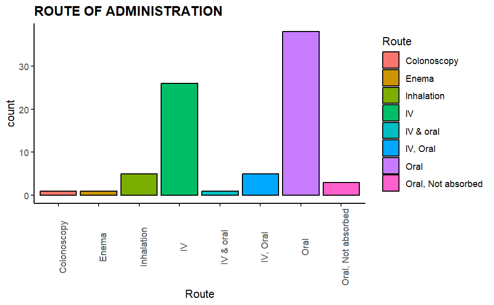

```r
# ROUTE OF ADMINISTRATION
Route <- AMR_PRODUCTS %>% select(Product.name, Route.of.administration)
Route <- distinct(Route)
Route <- as.data.frame(Route)
ggplot(data = Route, aes(x = Route.of.administration)) + geom_bar(aes(fill = Route.of.administration), color ="black")+ labs(title = "ROUTE OF ADMINISTRATION",  x = "Route", fill= "Route")+ theme_classic()+  theme(plot.title  = element_text(face = "bold"))+ theme(axis.text.x = element_text(angle = 90))
```

```r
Route
```

| Product.name | Route.of.administration |
| --- | --- |
| Bacteriophage | Inhalation |
| 9MW1411 | IV |
| AB103 | IV |
| Afabicin | IV, Oral |
| ALS-4 | Oral |
| AP-PA02 | Inhalation |
| AR-301 | IV |
| AR-302 | IV |
| ARX-1796 | Oral |
| Benapenem | IV |

[output cut: 70 more lines]

**Oral** is the most preferred route of administration, seconded by **IV**.

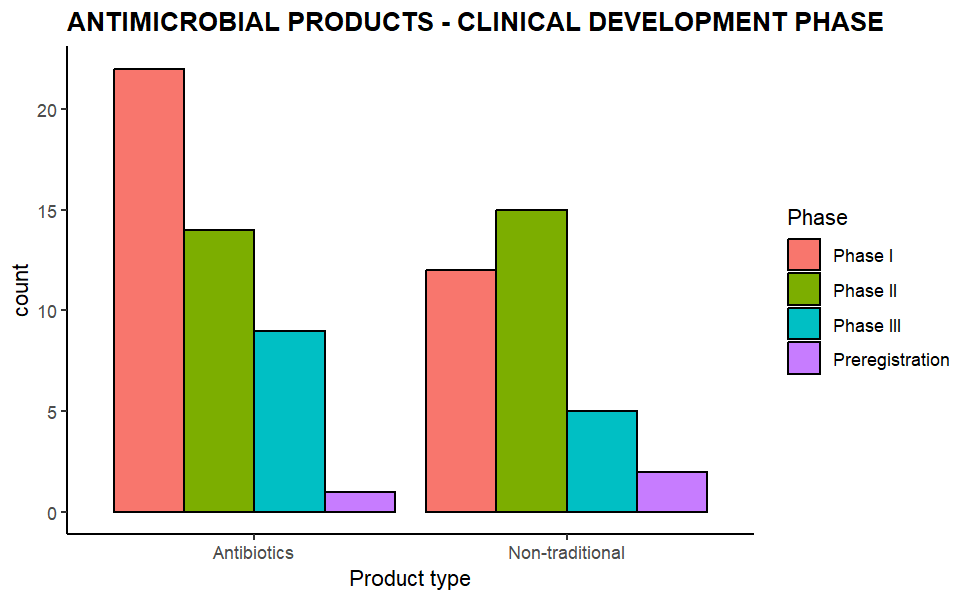

```r
# CLINICAL DEVELOPMENT PHASE OF PRODUCTS
Phase <- AMR_PRODUCTS %>% select( Product.name,R.D.phase, Product.type)
Phase <- distinct(Phase)
Phase <- as.data.frame(Phase)
ggplot(Phase, aes(x = Product.type, fill = R.D.phase )) + geom_bar(position = "dodge", color="black") + labs(title = "ANTIMICROBIAL PRODUCTS - CLINICAL DEVELOPMENT PHASE", fill = "Phase", x= "Product type")+ theme_classic()+  theme(plot.title  = element_text(face = "bold"))
```

```r
#Antibiotics - Clinical phase
AB_PHASE <- Antibiotics %>% select(Product.name, R.D.phase)
AB_PHASE <- distinct(AB_PHASE)
AB_PHASE
```

| Product.name | R.D.phase |
| --- | --- |
| Afabicin | Phase II |
| ARX-1796 | Phase I |
| Benapenem | Phase III |
| BWC0977 | Phase I |
| Delpazolid | Phase II |
| Durlobactam + sulbactam | Phase III |
| EBL-1003 | Phase I |
| Enmetazobactam + cefepime | Phase III |
| ETX0282 + cefpodoxime | Phase I |
| Gepotidacin | Phase III |

[output cut: 36 more lines]

```r
#Non-traditional - Clinical phase
NT_PHASE <- Non_traditional %>% select(Product.name, R.D.phase)
NT_PHASE <- distinct(NT_PHASE)
NT_PHASE
```

| Product.name | R.D.phase |
| --- | --- |
| Bacteriophage | Phase III |
| 9MW1411 | Phase I |
| AB103 | Preregistration |
| ALS-4 | Phase I |
| AP-PA02 | Phase II |
| AR-301 | Phase III |
| AR-302 | Phase II |
| BX004-A | Phase II |
| CAL02 | Phase I |
| CF-301 | Phase III |

[output cut: 24 more lines]

Information on the clinical development phase of the antimicrobial products is visualized and tabulated.

**Antibiotics:** Phase I - 22; Phase II - 14; Phase III - 9; Pre-registration - 1

**Non-traditional:** Phase I - 12; Phase II - 15; Phase III - 5; Pre-registration - 2

```r
#ANTIMICROBIALS INDICATION
AB_Indication <- Antibiotics %>% select(Product.name,Indications)
AB_Indication <- distinct(AB_Indication)
NT_Indication <- Non_traditional %>% select(Product.name,Indications)
NT_Indication <- distinct(NT_Indication)
#ANTIBIOTICS INDICATION
AB_Indication
```

| Product.name | Indications |
| --- | --- |
| Afabicin | ABSSI (caused by S. aureus), osteomyelitis |
| ARX-1796 | Gram-negative infections |
| Benapenem | cUTI |
| BWC0977 | Gram-negative and Gram-positive bacterial infections |
| Delpazolid | Pulmonary tuberculosis, \nGram-positive bacterial infections |
| Durlobactam + sulbactam | A. baumannii HAP, VAP |
| EBL-1003 | Bacterial infections |
| Enmetazobactam + cefepime | cUTI, AP |
| ETX0282 + cefpodoxime | Active against ESBL, OXA-48 and KPC, but not\n MBL-producing Enterobacterales |
| Gepotidacin | Uncomplicated urogenital gonorrhea and uUTI |

[output cut: 37 more lines]

```r
#NON-TRADITIONALS INDICATION
NT_Indication
```

| Product.name | Indications |
| --- | --- |
| Bacteriophage | Gram positive and Gram negative |
| 9MW1411 | S. aureus |
| AB103 | S. aureus necrotizing soft tissue infection,\nacute kidney injury, peritonitis |
| ALS-4 | S. aureus |
| AP-PA02 | CF subjects with P. aeruginosa infections |
| AR-301 | S. aureus HAP, VAP |
| AR-302 | S. aureus HAP, VAP |
| BX004-A | CF subjects with P. aeruginosa infections |
| CAL02 | S. pneumonia severe pneumonia |
| CF-301 | S. aureus bacteremia |

[output cut: 24 more lines]

```r
##(ggplot(data = AB_Indication) + geom_bar(mapping = aes( fill = Product.name, y = Indications), color="black") + labs(title = "ANTIBIOTICS INDICATION", y = "Indications", fill= "Product")+ theme_classic()+  theme(plot.title  = element_text(face = "bold"), legend.key.size = unit(0.2,"cm"), legend.text = element_text(size=5))+theme(axis.text.x = element_text(angle = 90))

##(ggplot(data = NT_Indication) + geom_bar(mapping = aes( fill = Product.name, y = Indications), color="black") + labs(title = "NON-TRADITIONAL PRODUCTS INDICATION", y = "Indications", fill= "Product")+ theme_classic()+  theme(plot.title  = element_text(face = "bold"),legend.key.size = unit(0.2,"cm"), legend.text = element_text(size=5))+theme(axis.text.x = element_text(angle = 90))
```

An **antimicrobial indication** refers to specific condition or infection for which an antimicrobial agent is recommended or prescribed.

The indication for antibiotics and non-traditional products is tabulated individually. Plots were not visualized due to spatial inconvenience.

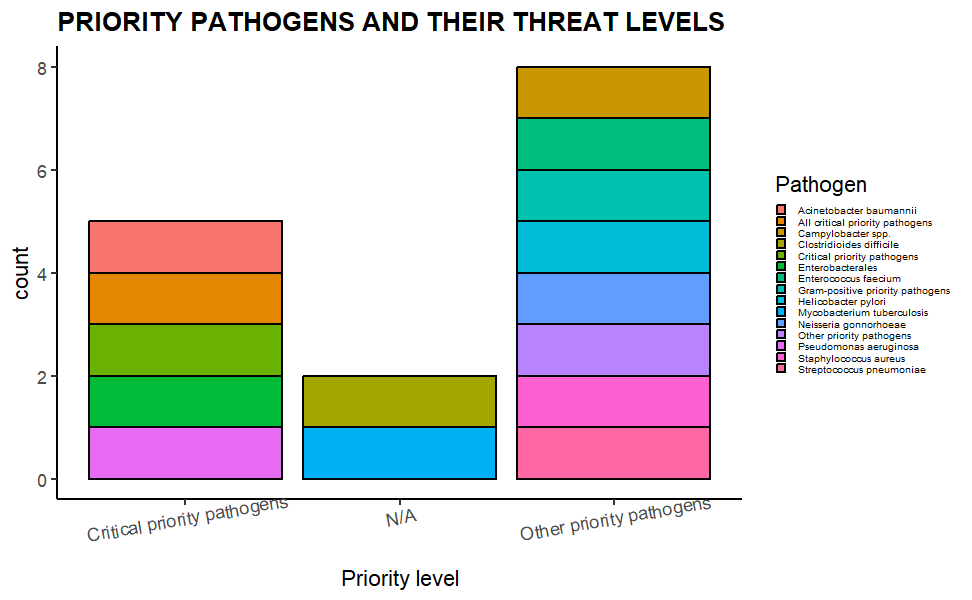

```r
#PRIORITY PATHOGENS AND THEIR THREAT LEVELS
priority <- AMR_PRODUCTS %>% select(Pathogen.name,Pathogen.activity)
priority <- distinct(priority)
priority <- as.data.frame(priority)
ggplot(data = priority) + geom_bar(mapping = aes( fill = Pathogen.name, x = Pathogen.activity), color="black") + labs(title = "PRIORITY PATHOGENS AND THEIR THREAT LEVELS", x = "Priority level", fill= "Pathogen")+ theme_classic()+  theme(plot.title  = element_text(face = "bold"),legend.key.size = unit(0.2,"cm"), legend.text = element_text(size=5))+theme(axis.text.x = element_text(angle = 10))
```

```r
priority
```

| Pathogen.name | Pathogen.activity |
| --- | --- |
| Streptococcus pneumoniae | Other priority pathogens |
| Staphylococcus aureus | Other priority pathogens |
| Pseudomonas aeruginosa | Critical priority pathogens |
| Other priority pathogens | Other priority pathogens |
| Neisseria gonnorhoeae | Other priority pathogens |
| Helicobacter pylori | Other priority pathogens |
| Gram-positive priority pathogens | Other priority pathogens |
| Enterococcus faecium | Other priority pathogens |
| Enterobacterales | Critical priority pathogens |
| Critical priority pathogens | Critical priority pathogens |

[output cut: 5 more lines]

The threat level of priority pathogens were visualized and tabulated.

**Critical priority pathogens** pose the most urgent threat due to their resistant towards multiple antimicrobial products. Pathogens like *Pseudomonas aeruginosa, Enterobacterales, Acinetobacter baumannii* falls under this category.

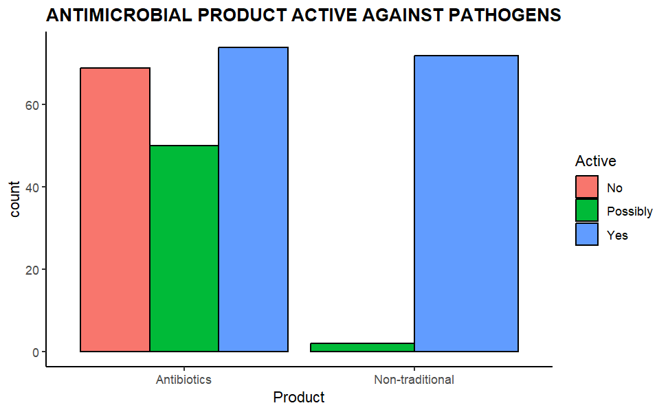

```r
#ACTIVITY OF PRODUCTS AGAINST PRIORITY PATHOGEN
Activity <- AMR_PRODUCTS %>% select( Active.against.priority.pathogens., Product.type)
Activity <- lapply(Activity, function(x) ifelse(x == "N/A", NA, x))
Activity <- as.data.frame(Activity)
Activity <- na.omit(Activity)
ggplot(Activity, aes(x = Product.type, fill = Active.against.priority.pathogens. )) + geom_bar(position = "dodge", color="black")  + labs(title = "ANTIMICROBIAL PRODUCT ACTIVE AGAINST PATHOGENS", fill = "Active", x= "Product")+ theme_classic()+  theme(plot.title  = element_text(face = "bold"))
```

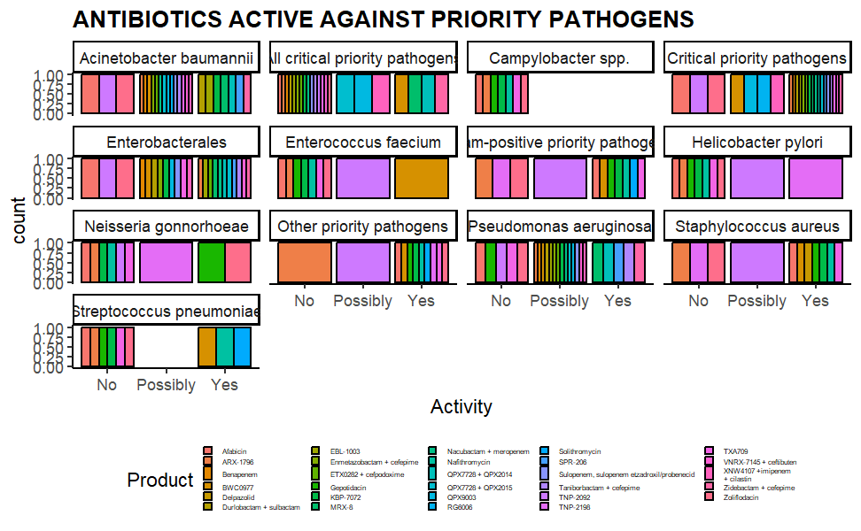

```r
#ANTIBIOTICS ACTIVE AGAINST PRIORITY PATHOGENS
AB_Activity <- Antibiotics %>% select(Product.name,Pathogen.name,Active.against.priority.pathogens.)
AB_Activity <- distinct(AB_Activity)
AB_Activity <- lapply(AB_Activity, function(x) ifelse(x == "N/A", NA, x))
AB_Activity <- as.data.frame(AB_Activity)
AB_Activity <- na.omit(AB_Activity)
ggplot(AB_Activity, aes(x =Active.against.priority.pathogens., fill = Product.name )) + geom_bar(position = "dodge", color="black") + facet_wrap(~ Pathogen.name) + labs(title = "ANTIBIOTICS ACTIVE AGAINST PRIORITY PATHOGENS", x = "Activity", fill= "Product")+ theme_classic()+  theme(plot.title  = element_text(face = "bold"),legend.position = "bottom", legend.key.size = unit(0.2,"cm"), legend.text = element_text(size=4))
```

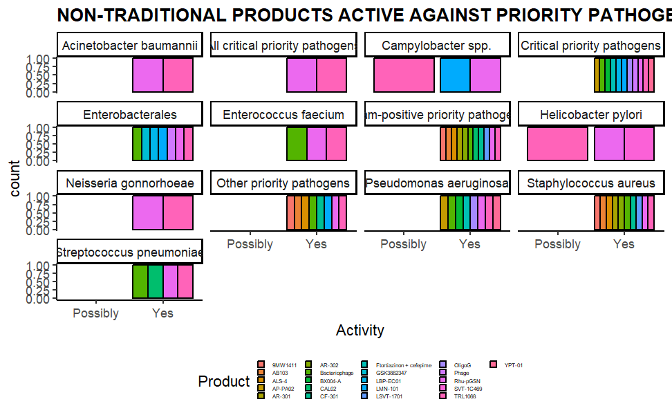

```r
#NON-TRADITIONALS ACTIVE AGAINST PRIORITY PATHOGENS
NT_Activity <- Non_traditional %>% select(Product.name,Pathogen.name,Active.against.priority.pathogens.)
NT_Activity <- distinct(NT_Activity)
NT_Activity <- lapply(NT_Activity, function(x) ifelse(x == "N/A", NA, x))
NT_Activity <- as.data.frame(NT_Activity)
NT_Activity <- na.omit(NT_Activity)
ggplot(NT_Activity, aes(x =Active.against.priority.pathogens., fill = Product.name )) + geom_bar(position = "dodge", color="black") + facet_wrap(~ Pathogen.name) + labs(title = "NON-TRADITIONAL PRODUCTS ACTIVE AGAINST PRIORITY PATHOGENS", x = "Activity", fill= "Product")+ theme_classic()+  theme(plot.title  = element_text(face = "bold"),legend.position = "bottom",legend.key.size = unit(0.2,"cm"), legend.text = element_text(size=4))
```

Antibiotics and non-traditional products that are active against priority pathogens are visualized.

Antibiotics **ARF-1796,TXA709, QPX7728+QPX2014** are active against most of the pathogens. **Afabicin** is inactive to be the most inactive.

Non-traditional products **TRL1068,phage,bacteriophage and BX004-A** are found to be predominantly active against most of the pathogens.

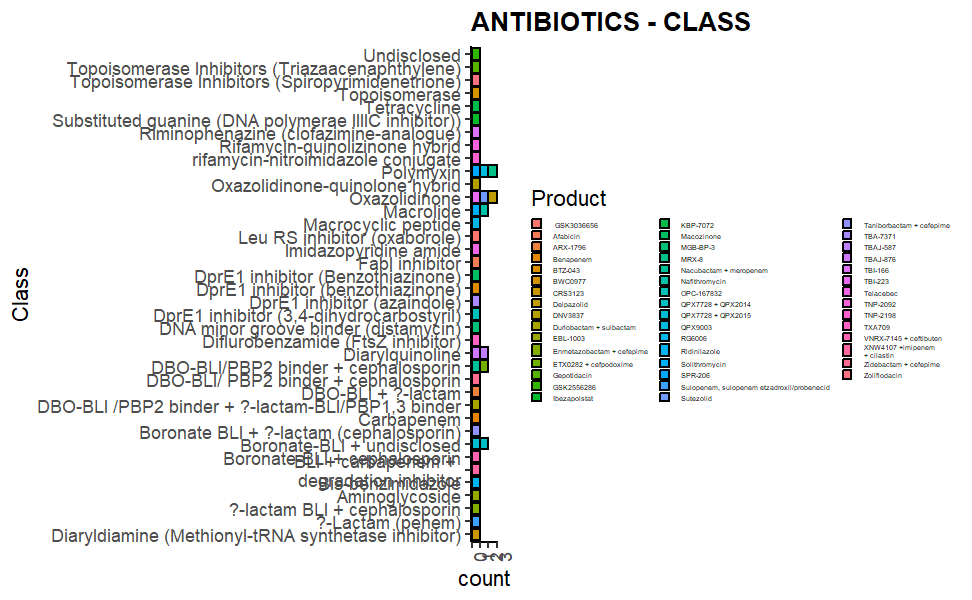

```r
#ANTIBACTERIAL CLASS
AB_product_class <- Antibiotics %>% select(Product.name,Antibacterial.class)
AB_product_class <- distinct(AB_product_class)
AB_product_class <- as.data.frame(AB_product_class)
NT_product_class <- Non_traditional %>% select(Product.name,Antibacterial.class)
NT_product_class <- distinct(NT_product_class)
NT_product_class <- as.data.frame(NT_product_class)
#ANTIBIOTICS
ggplot(data = AB_product_class) + geom_bar(mapping = aes( fill = Product.name, y = Antibacterial.class), color="black") + labs(title = "ANTIBIOTICS - CLASS", y = "Class", fill= "Product")+ theme_classic()+  theme(plot.title  = element_text(face = "bold"),legend.key.size = unit(0.2,"cm"), legend.text = element_text(size=3.5))+theme(axis.text.x = element_text(angle = 90))
```

```r
AB_product_class
```

| Product.name | Antibacterial.class |
| --- | --- |
| Afabicin | FabI inhibitor |
| ARX-1796 | DBO-BLI + ?-lactam |
| Benapenem | Carbapenem |
| BWC0977 | Topoisomerase |
| Delpazolid | Oxazolidinone |
| Durlobactam + sulbactam | DBO-BLI /PBP2 binder + ?-lactam-BLI/PBP1,3 binder |
| EBL-1003 | Aminoglycoside |
| Enmetazobactam + cefepime | ?-lactam BLI + cephalosporin |
| ETX0282 + cefpodoxime | DBO-BLI/PBP2 binder + cephalosporin |
| Gepotidacin | Topoisomerase Inhibitors (Triazaacenaphthylene) |

[output cut: 36 more lines]

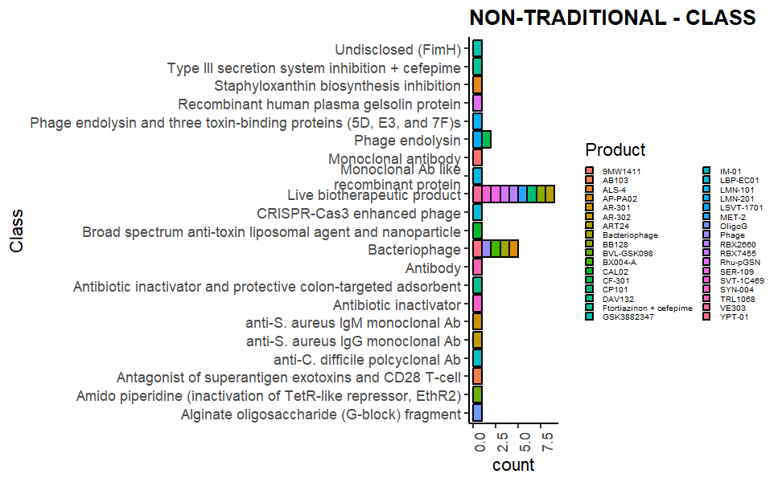

```r
#NON-TRADITIONALS
ggplot(data = NT_product_class) + geom_bar(mapping = aes( fill = Product.name, y = Antibacterial.class), color="black") + labs(title = "NON-TRADITIONAL - CLASS", y = "Class", fill= "Product")+ theme_classic()+  theme(plot.title  = element_text(face = "bold"),legend.key.size = unit(0.2,"cm"), legend.text = element_text(size=5))+theme(axis.text.x = element_text(angle = 90))
```

```r
NT_product_class
```

| Product.name | Antibacterial.class |
| --- | --- |
| Bacteriophage | Bacteriophage |
| 9MW1411 | Monoclonal antibody |
| AB103 | Antagonist of superantigen exotoxins and CD28 T-cell |
| ALS-4 | Staphyloxanthin biosynthesis inhibition |
| AP-PA02 | Bacteriophage |
| AR-301 | anti-S. aureus IgM monoclonal Ab |
| AR-302 | anti-S. aureus IgG monoclonal Ab |
| BX004-A | Bacteriophage |
| CAL02 | Broad spectrum anti-toxin liposomal agent and nanoparticle |
| CF-301 | Phage endolysin |

[output cut: 24 more lines]

Antibacterial class of antibiotics and non-traditional products are visualized and tabulated.

Major **non-traditional** products lie under the class **Live bio-therapeutic product**.

```r
#DEVELOPERS
Developer <- AMR_PRODUCTS %>% select(Product.name,Developer)
Developer <- distinct(Developer)
Developer <- as.data.frame(Developer)
Developer
```

| Product.name | Developer |
| --- | --- |
| Bacteriophage | Tashkent Pediatric Medical\nInstitute |
| 9MW1411 | Mabwell Bioscience |
| AB103 | Atox Bio |
| Afabicin | Debiopharm International SA |
| ALS-4 | Aptorum Group |
| AP-PA02 | Armata Pharmaceuticals |
| AR-301 | Aridis Pharmaceuticals, Inc. |
| AR-302 | Aridis\nAstraZeneca/ MedImmune |
| ARX-1796 | Pfizer/ Arixa Pharmaceuticals |
| Benapenem | Sichuan Pharmaceutical Holdings Group Ltd |

[output cut: 70 more lines]

The developers of the antimicrobial products are tabulated.

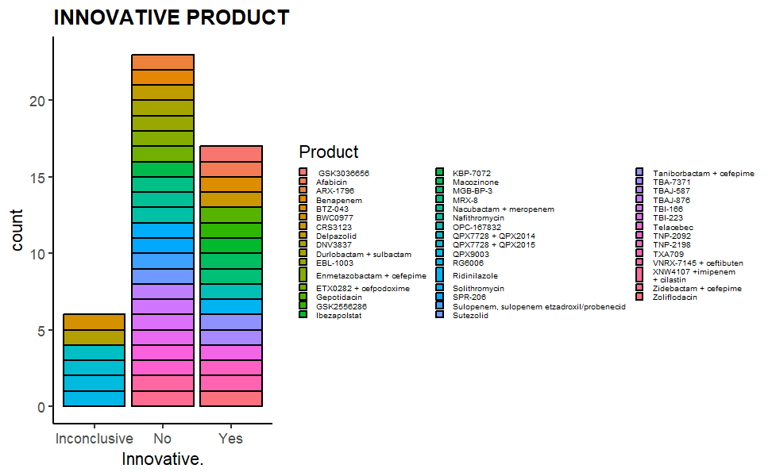

```r
#INNOVATIVENESS OF THE PRODUCTS
Innovativeness <- AMR_PRODUCTS %>% select(Product.name,Innovative.)
Innovativeness <- distinct(Innovativeness)
Innovativeness <- lapply(Innovativeness, function(x) ifelse(x == "N/A", NA, x))
Innovativeness <- as.data.frame(Innovativeness)
Innovativeness <- na.omit(Innovativeness)
ggplot(data = Innovativeness) + geom_bar(mapping = aes( fill = Product.name, x = Innovative.), color="black") + labs(title = "INNOVATIVE PRODUCT", X = "Innovativenss", fill= "Product")+ theme_classic()+  theme(plot.title  = element_text(face = "bold"),legend.key.size = unit(0.2,"cm"), legend.text = element_text(size=5))
```

```r
Innovativeness
```

|  | Product.name | Innovative. |
| --- | --- | --- |
| 4 | Afabicin | Yes |
| 9 | ARX-1796 | No |
| 10 | Benapenem | No |
| 11 | BWC0977 | Inconclusive |
| 15 | Delpazolid | No |
| 16 | Durlobactam + sulbactam | No |
| 17 | EBL-1003 | No |
| 18 | Enmetazobactam + cefepime | No |
| 19 | ETX0282 + cefpodoxime | No |
| 21 | Gepotidacin | Yes |

[output cut: 36 more lines]

Among the 80 products, 17 are found to be innovative.

**TXA709** - *Active against most of the priority pathogens.*

*THE DATA WAS SEGMENTED INTO SUBSETS TO REMOVE DUPLICATES AND OBTAIN MEANINGFUL RESULTS*